# Exploring the Relationship Between Infrastructure and Collisions

Author

Sarah Susnea

# Introduction

The data used was sourced from NYC’s Open Data project which aims to make data about the city available to the public. I selected two data sets from NYC Open Data, one about car crashes within the city, and another about the bike routes within the city. In the introduction for the accidents data set, it is stated that a police report is required for collisions where someone is injured or killed or where there are at least $1,000 worth of damage [^1]. This data is collected as a part of New York’s larger project, Vision Zero, which aims to reduce traffic fatalities to zero. For my second data frame, NYC divides bike infrastructure into 4 larger categories: protected bike lanes, painted bike lanes, often indicated with sharrows, and signed routes [^2]. Through my maps and analysis, I was hoping to establish a correlation between the kind of infrastructure and the severity of a collision. Are painted bike lanes sufficient? What’s the best form of bike infrastructure to keep a cyclist safe? These questions can be answered not only by looking at what is plotted on the map, but also at what isn’t.

# Static Map

This map shows the collisions involving bikes and/or e-bikes in northern Brooklyn for 2020. This data is mapped on top of the bike routes of this area as of 2020. Each blue point on the map is a collision, and the opacity corresponds to the number of cyclists injured in the collision. The bike routes are represented in different colors according to their classifications. Points which are mapped off of the colored lines can be assumed to have occurred on streets without any sort of bike infrastructure. This map shows that while there are collisions which occur on streets without any kind of bike infrastructure, a significant number of these collisions occur on streets that are classified as “standard.” Although this does technically count as infrastructure, I would argue that this is largely ineffective infrastructure due to the frequency of collisions I can observe on this map.

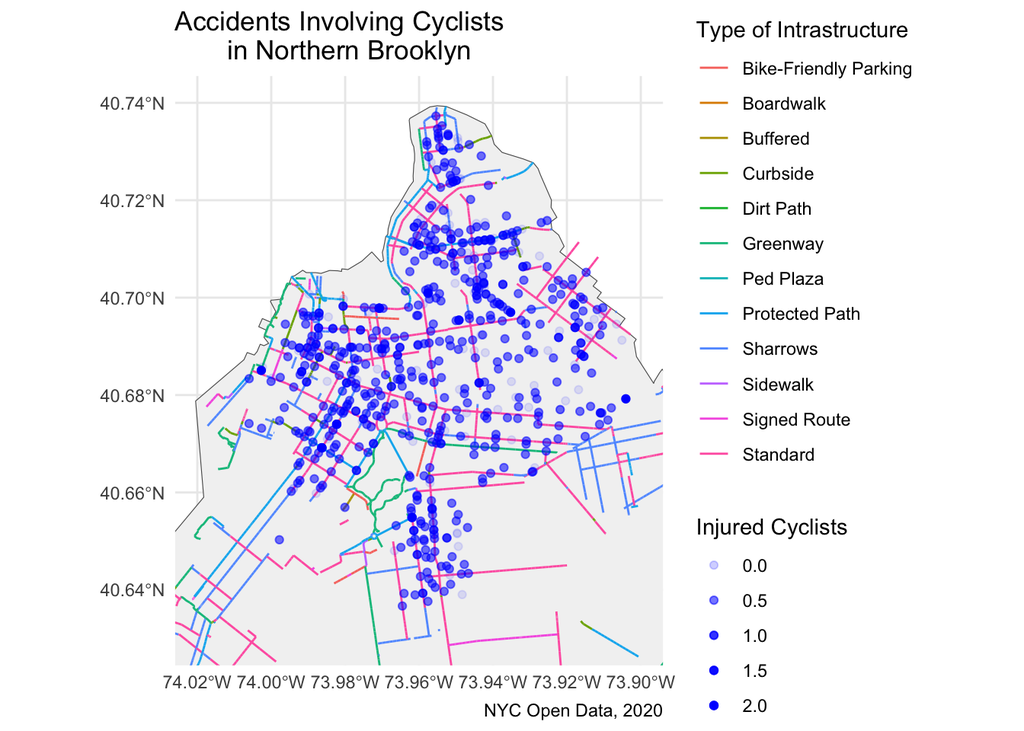

# Interactive Map

This interactive map shows the same data set: collisions involving bikes and/or e-bikes in northern Brooklyn for 2020. Each point represents a collision, and clicking on these points tells the viewer the types of vehicles involved in a collision. Zooming out groups the points together, allowing me to better see areas where crashes are clustered together. Additionally, clicking on the bike routes tells me the classification of that route. The interactive map provides more context and detail, allowing me to see the area in which the collisions occurred. For example, I can see a collision on Fulton Street between a bike and sedan on a route classified as a sharrow. I can also see that on infrastructure like a protected path, there are no collisions. This interactive map better demonstrates how effective certain classifications of bike infrastructure are over others.

[interactive chart not shown]

## Footnotes

[^1]: https://data.cityofnewyork.us/Public-Safety/Motor-Vehicle-Collisions-Crashes/h9gi-nx95
[^2]: https://www.nyc.gov/html/dot/downloads/pdf/dot_bikesmart_brochure.pdf